# Reproducibility Report: Group B Choice 3

For this exercise, please try to reproduce the results from Experiment 2 of the associated paper (de la Fuente, Santiago, Roman, Dumitrache, & Casasanto, 2014). The PDF of the paper is included in the same folder as this Rmd file.

#### Methods summary:

Researchers tested the question of whether temporal focus differs between Moroccan and Spanish cultures, hypothesizing that Moroccans are more past-focused, whereas Spaniards are more future-focused. Two groups of participants ($N = 40$ Moroccan and $N=40$ Spanish) completed a temporal-focus questionnaire that contained questions about past-focused (“PAST”) and future-focused (“FUTURE”) topics. In response to each question, participants provided a rating on a 5-point Likert scale on which lower scores indicated less agreement and higher scores indicated greater agreement. The authors then performed a mixed-design ANOVA with agreement score as the dependent variable, group (Moroccan or Spanish, between-subjects) as the fixed-effects factor, and temporal focus (past or future, within-subjects) as the random effects factor. In addition, the authors performed unpaired two-sample t-tests to determine whether there was a significant difference between the two groups in agreement scores for PAST questions, and whether there was a significant difference in scores for FUTURE questions.

#### Target outcomes:

Below is the specific result you will attempt to reproduce (quoted directly from the results section of Experiment 2):

> According to a mixed analysis of variance (ANOVA) with group (Spanish vs. Moroccan) as a between-subjects factor and temporal focus (past vs. future) as a within-subjectS factor, temporal focus differed significantly between Spaniards and Moroccans, as indicated by a significant interaction of temporal focus and group, F(1, 78) = 19.12, p = .001, ηp2 = .20 (Fig. 2). Moroccans showed greater agreement with past-focused statements than Spaniards did, t(78) = 4.04, p = .001, and Spaniards showed greater agreement with future-focused statements than Moroccans did, t(78) = −3.32, p = .001. (de la Fuente et al., 2014, p. 1685).

# Step 1: Load packages

```r
library(tidyverse) # for data munging
library(knitr) # for kable table formating
library(haven) # import and export 'SPSS', 'Stata' and 'SAS' Files
library(readxl) # import excel files
library(rstatix)

# #optional packages/functions:
# library(afex) # anova functions
# library(ez) # anova functions 2
# library(scales) # for plotting
# std.err <- function(x) sd(x)/sqrt(length(x)) # standard error
```

# Step 2: Load data

```r
# Just Experiment 2
data_path <- 'data/DeLaFuenteEtAl_2014_RawData.xls'
d <- read_excel(data_path, sheet=3)
```

# Step 3: Tidy data

```r
d = rename(d, Agreement = "Agreement (0=complete disagreement; 5=complete agreement)")
```

```r
is_empty(d)
```

```
## [1] FALSE
```

```r
colnames(d)
```

```
## [1] "group"       "participant" "subscale"    "item"        "Agreement"
```

# Step 4: Run analysis

## Pre-processing

```r
tidy_d =d %>%
  group_by(participant, group, subscale) %>%
  summarise(Mean_participant_rating = mean(Agreement))
tidy_d
```

```
## # A tibble: 158 × 4
## # Groups:   participant, group [80]
##    participant group          subscale Mean_participant_rating
##          <dbl> <chr>          <chr>                      <dbl>
##  1           1 Moroccan       FUTURE                      3.3
##  2           1 Moroccan       PAST                        3.36
##  3           1 young Spaniard FUTURE                      3.3
##  4           1 young Spaniard PAST                        2.55
##  5           2 Moroccan       FUTURE                      3.2
##  6           2 Moroccan       PAST                        3.82
##  7           2 young Spaniard FUTURE                      3.6
##  8           2 young Spaniard PAST                        3.91
##  9           3 Moroccan       FUTURE                      3.2
## 10           3 Moroccan       PAST                        3.18
## # … with 148 more rows
```

```r
nrow(tidy_d)
```

```
## [1] 158
```

```r
summary_d = d %>%
  group_by(group, subscale)  %>%
summarize(Rating = mean(Agreement), sem = sd(Agreement)/sqrt(length(Agreement)))

summary_d
```

```
## # A tibble: 4 × 4
## # Groups:   group [2]
##   group          subscale Rating    sem
##   <chr>          <chr>     <dbl>  <dbl>
## 1 Moroccan       FUTURE     3.12 0.0698
## 2 Moroccan       PAST       3.29 0.0698
## 3 young Spaniard FUTURE     3.49 0.0600
## 4 young Spaniard PAST       2.68 0.0578
```

```r
level_order <- factor(summary_d$group, level = c('young Spaniard', 'Moroccan'))
scale_order <- factor(summary_d$subscale, level = c('PAST', 'FUTURE'))
```

## Descriptive statistics

Try to recreate Figure 2 (fig2.png, also included in the same folder as this Rmd file):

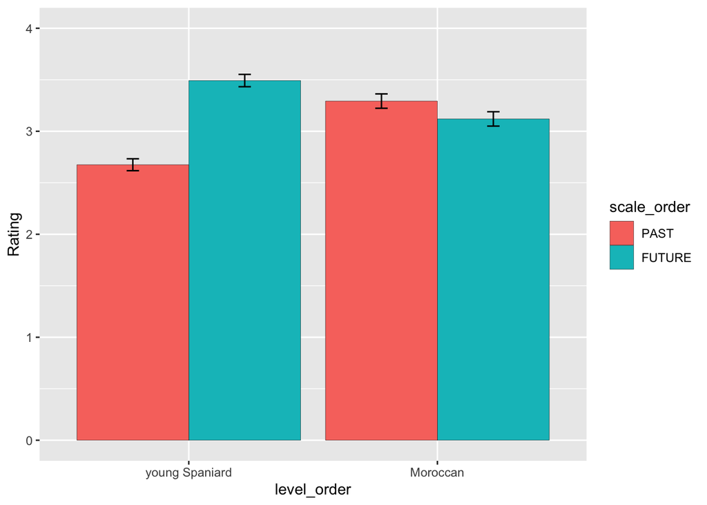

```r
p<-ggplot(data=summary_d, aes(x=level_order, y=Rating, fill = scale_order)) +
  geom_bar(position="dodge", stat="identity",colour="black", # Use black outlines,
             size=.1) +
  geom_errorbar(aes(ymin=Rating-sem, ymax=Rating+sem),width=.1,position=position_dodge(.9)) +
  ylim(0, 4.0)
p
```

## Inferential statistics

> According to a mixed analysis of variance (ANOVA) with group (Spanish vs. Moroccan) as a between-subjects factor and temporal focus (past vs. future) as a within-subjects factor, temporal focus differed significantly between Spaniards and Moroccans, as indicated by a significant interaction of temporal focus and group, F(1, 78) = 19.12, p = .001, ηp2 = .20 (Fig. 2).

```r
# reproduce the above results here
d %>% anova_test(Agreement ~ group *  subscale)
```

```
## ANOVA Table (type II tests)
##
##           Effect DFn  DFd      F        p p<.05   ges
## 1          group   1 1676  5.137 2.40e-02     * 0.003
## 2       subscale   1 1676 24.811 6.98e-07     * 0.015
## 3 group:subscale   1 1676 58.655 3.16e-14     * 0.034
```

> Moroccans showed greater agreement with past-focused statements than Spaniards did, t(78) = 4.04, p = .001,

```r
# reproduce the above results here
t.test(Mean_participant_rating ~ group, data = filter(tidy_d, subscale == "PAST") )
```

```
##
##  Welch Two Sample t-test
##
## data:  Mean_participant_rating by group
## t = 3.8562, df = 74.91, p-value = 0.0002416
## alternative hypothesis: true difference in means between group Moroccan and group young Spaniard is not equal to 0
## 95 percent confidence interval:
##  0.2850812 0.8944060
## sample estimates:
##       mean in group Moroccan mean in group young Spaniard
##                     3.280886                     2.691142
```

> and Spaniards showed greater agreement with future-focused statements than Moroccans did, t(78) = −3.32, p = .001.(de la Fuente et al., 2014, p. 1685)

```r
# reproduce the above results here
t.test(Mean_participant_rating ~ group, data = filter(tidy_d, subscale == "FUTURE") )
```

```
##
##  Welch Two Sample t-test
##
## data:  Mean_participant_rating by group
## t = -3.2098, df = 70.047, p-value = 0.002005
## alternative hypothesis: true difference in means between group Moroccan and group young Spaniard is not equal to 0
## 95 percent confidence interval:
##  -0.5762537 -0.1345797
## sample estimates:
##       mean in group Moroccan mean in group young Spaniard
##                     3.138333                     3.493750
```

# Step 5: Reflection

Were you able to reproduce the results you attempted to reproduce? If not, what part(s) were you unable to reproduce?

> I was able to reproduce the descriptive stats, but not the inferential stats.

How difficult was it to reproduce your results?

> Medium difficult.

What aspects made it difficult? What aspects made it easy?

> I think the ANOVA part was difficult because I was not sure which specific setting I should use. And I was also unsure which t-test I should use.